# EDA and Modeling of Health Data

Ada Lazuli

2022-06-20

# Data Exploration Of [Heart Data](https://learn.umgc.edu/content/enforced/685926-027339-01-2225-GO1-9041/Dataset%20Descriptions/whas500.txt)

## Initial Data Inspection

```r
df <- read.csv("whas500.csv")
str(df)
```

```
## 'data.frame':    500 obs. of  22 variables:
##  $ id       : int  1 2 3 4 5 6 7 8 9 10 ...
##  $ age      : int  83 49 70 70 70 70 57 55 88 54 ...
##  $ gender   : int  0 0 1 0 0 0 0 0 1 0 ...
##  $ hr       : int  89 84 83 65 63 76 73 91 63 104 ...
##  $ sysbp    : int  152 120 147 123 135 83 191 147 209 166 ...
##  $ diasbp   : int  78 60 88 76 85 54 116 95 100 106 ...
##  $ bmi      : num  25.5 24 22.1 26.6 24.4 ...
##  $ cvd      : int  1 1 0 1 1 1 1 1 1 1 ...
##  $ afb      : int  1 0 0 0 0 0 0 0 0 0 ...
##  $ sho      : int  0 0 0 0 0 0 0 0 0 0 ...
##  $ chf      : int  0 0 0 1 0 0 0 0 1 0 ...
##  $ av3      : int  0 0 0 0 0 1 0 0 0 0 ...
##  $ miord    : int  1 0 0 0 0 0 0 0 0 0 ...
##  $ mitype   : int  0 1 1 1 1 0 1 1 0 0 ...
##  $ year     : int  1 1 1 1 1 1 1 1 1 1 ...
##  $ admitdate: chr  "1/13/1997" "1/19/1997" "1/1/1997" "2/17/1997" ...
##  $ disdate  : chr  "1/18/1997" "1/24/1997" "1/6/1997" "2/27/1997" ...
##  $ fdate    : chr  "12/31/2002" "12/31/2002" "12/31/2002" "12/11/1997" ...
##  $ los      : int  5 5 5 10 6 1 5 4 4 5 ...
##  $ dstat    : int  0 0 0 0 0 1 0 0 0 0 ...
##  $ lenfol   : int  2178 2172 2190 297 2131 1 2122 1496 920 2175 ...
##  $ fstat    : int  0 0 0 1 0 1 0 1 1 0 ...
```

The data consists of 500 observations, 22 variables, and exactly 0 missing values.

The id field can be dropped from the data set, as it does not provide useful information.

```r
df <- df[, -1]
```

Next, the admittance date, discharge date, and the follow up date can be removed

```r
df <- df[, c(-15,-16,-17)]
```

Finally remove the length of hospital stay, total length of follow-up, and vital status at the last follow-up

```r
df <- df[, c(-15, -17, -18)]
colnames(df)
```

```
##  [1] "age"    "gender" "hr"     "sysbp"  "diasbp" "bmi"    "cvd"    "afb"
##  [9] "sho"    "chf"    "av3"    "miord"  "mitype" "year"   "dstat"
```

### Age

The age is a discrete quantitative variable that describes the age of the individual when they were admitted to the hospital.

```r
summary(df$age)
```

```
##    Min. 1st Qu.  Median    Mean 3rd Qu.    Max.
##   30.00   59.00   72.00   69.85   82.00  104.00
```

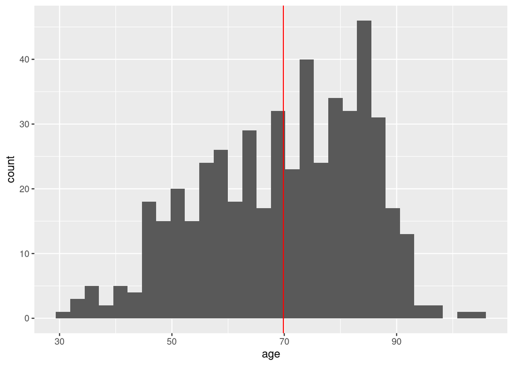

```r
ggplot(df, aes(x = age)) + geom_histogram() + geom_vline(aes(xintercept = mean(df$age)), color = "red")
```

There were 0 outliers found in the data for age.

### gender

The gender variable refers to the gender of the individual admitted to the hospital.

```r
print(table(df$gender))
```

```
##
##   0   1
## 300 200
```

### hr (Initial Heart Rate)

The initial heart rate of the individual admitted to the hospital

```r
summary(df$hr)
```

```
##    Min. 1st Qu.  Median    Mean 3rd Qu.    Max.
##   35.00   69.00   85.00   87.02  100.25  186.00
```

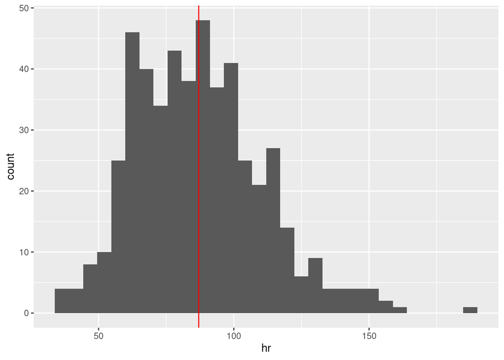

```r
ggplot(df, aes(x = hr)) + geom_histogram() + geom_vline(aes(xintercept = mean(df$hr)), color = "red")
```

### sysbp (Systolic Blood Pressure)

The Systolic Blood Pressure of the individual admitted to the hospital

```r
summary(df$sysbp)
```

```
##    Min. 1st Qu.  Median    Mean 3rd Qu.    Max.
##    57.0   123.0   141.5   144.7   164.0   244.0
```

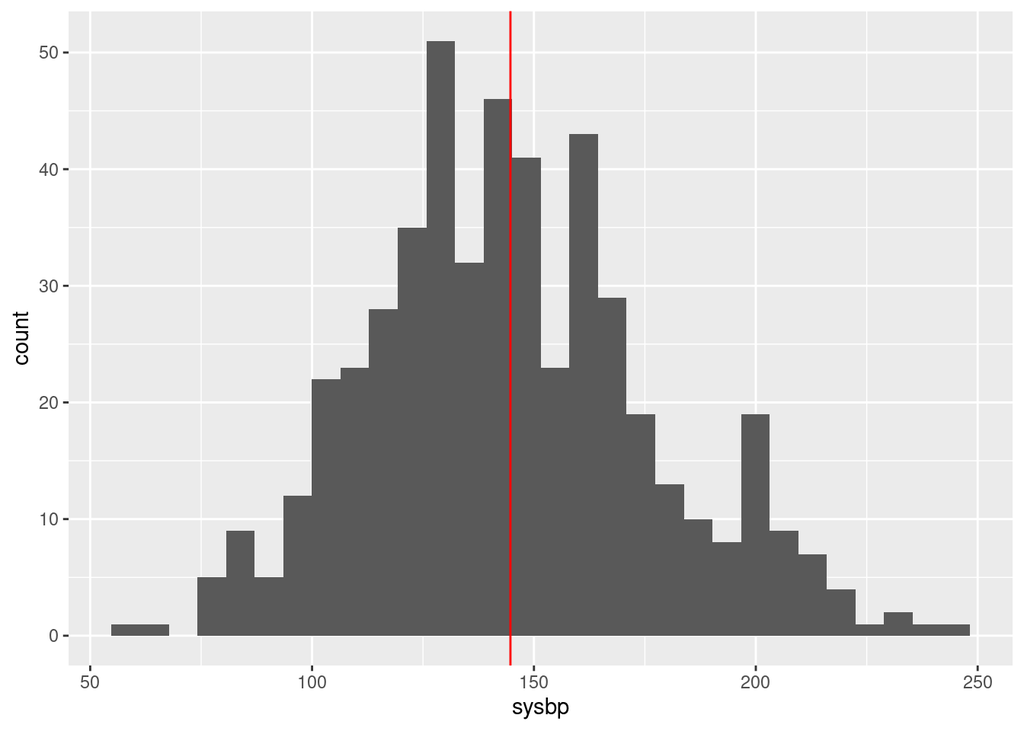

```r
ggplot(df, aes(x = sysbp)) + geom_histogram() + geom_vline(aes(xintercept = mean(df$sysbp)), color = "red")
```

### diasbp (Diastolic Blood Pressure)

The Diastolic Blood Pressure of the individual admitted to the hospital

```r
summary(df$diasbp)
```

```
##    Min. 1st Qu.  Median    Mean 3rd Qu.    Max.
##    6.00   63.00   79.00   78.27   91.25  198.00
```

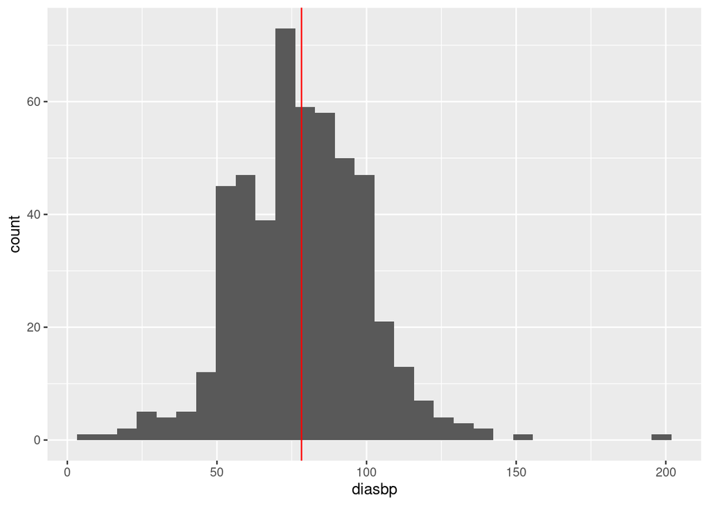

```r
ggplot(df, aes(x = diasbp)) + geom_histogram() + geom_vline(aes(xintercept = mean(df$diasbp)), color = "red")
```

### bmi

The BMI of the individual admitted to the hospital

```r
summary(df$bmi)
```

```
##    Min. 1st Qu.  Median    Mean 3rd Qu.    Max.
##   13.05   23.22   25.95   26.61   29.39   44.84
```

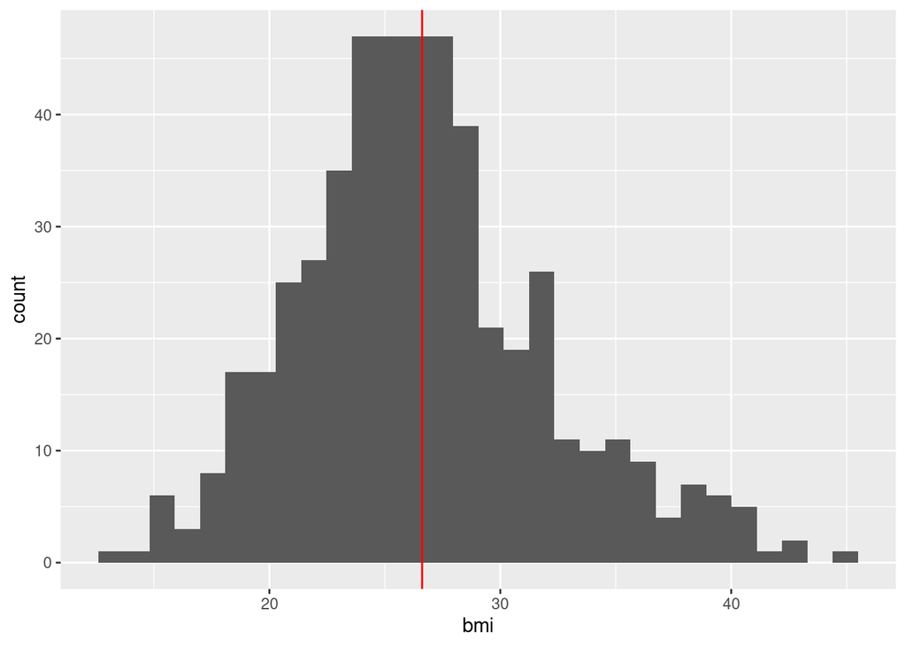

```r
ggplot(df, aes(x = bmi)) + geom_histogram() + geom_vline(aes(xintercept = mean(df$bmi)), color = "red")
```

### cvd

The cvd variable refers to History of Cardiovascular Disease of the individual admitted to the hospital.

```r
print(table(df$cvd))
```

```
##
##   0   1
## 125 375
```

### afb

The afb variable refers to Atrial Fibrillation of the individual admitted to the hospital.

```r
print(table(df$afb))
```

```
##
##   0   1
## 422  78
```

### sho

The sho variable refers to Cardiogenic Shock of the individual admitted to the hospital.

```r
print(table(df$sho))
```

```
##
##   0   1
## 478  22
```

### chf

The chf variable refers to Congestive Heart Complications of the individual admitted to the hospital.

```r
print(table(df$chf))
```

```
##
##   0   1
## 345 155
```

### av3

The av3 variable refers to Complete Heart Block of the individual admitted to the hospital.

```r
print(table(df$av3))
```

```
##
##   0   1
## 489  11
```

### miord

The miord variable refers to MI Order of the individual admitted to the hospital.

```r
print(table(df$miord))
```

```
##
##   0   1
## 329 171
```

### mitype

The mitype variable refers to MI Type of the individual admitted to the hospital.

```r
print(table(df$mitype))
```

```
##
##   0   1
## 347 153
```

### year

The year variable refers to Cohort Year of the individual admitted to the hospital.

```r
print(table(df$year))
```

```
##
##   1   2   3
## 160 188 152
```

### dstat

The dstat variable refers to Discharge Status of the individual admitted to the hospital.

```r
print(table(df$dstat))
```

```
##
##   0   1
## 461  39
```

# Reviewing difference in collection groups

The data was collected in 3 different time periods. This section compares those time periods for to determine if they are similar or not.

### age

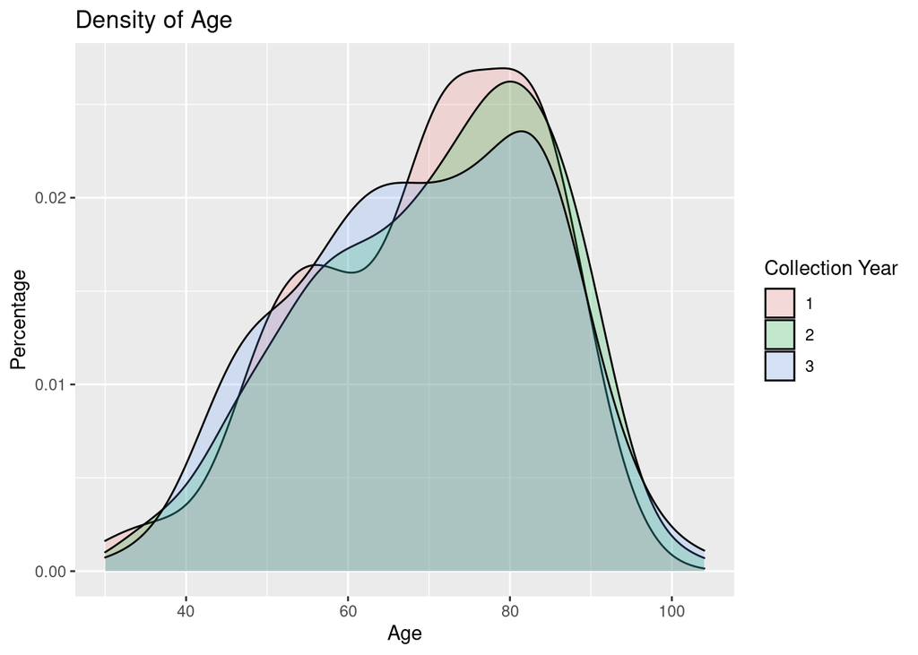

```r
ggplot(df, aes(x = age, fill = as.factor(year)))  + geom_density(alpha = 0.2) +  labs(x = "Age", y = "Percentage", fill = "Collection Year", title = "Density of Age")
```

### gender

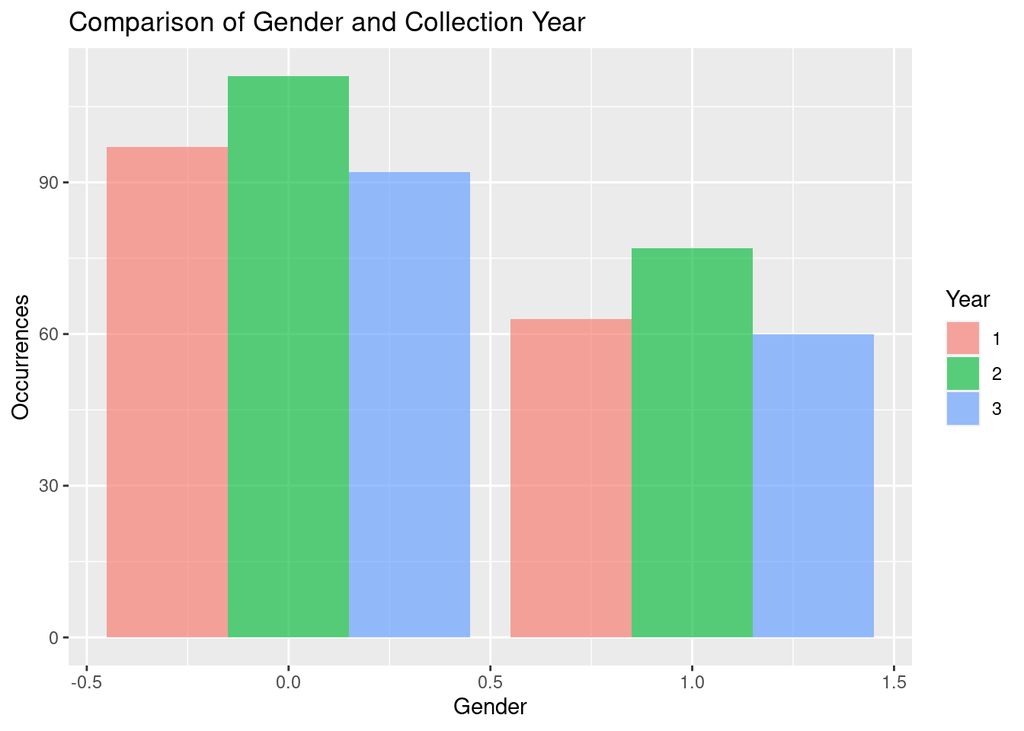

```r
ggplot(df, aes(x = gender, fill = as.factor(year))) + geom_bar(alpha = 0.4, position="dodge") + geom_bar(alpha = 0.4, position="dodge") +  labs(x = "Gender", y = "Occurrences", fill = "Year", title = "Comparison of Gender and Collection Year")
```

### hr

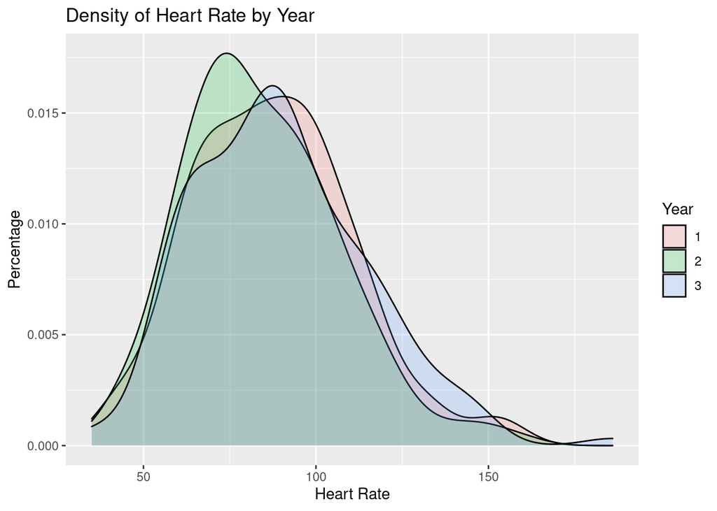

```r
ggplot(df, aes(x = hr, fill = as.factor(year)))  + geom_density(alpha = 0.2) +  labs(x = "Heart Rate", y = "Percentage", fill = "Year", title = "Density of Heart Rate by Year")
```

### sysbp

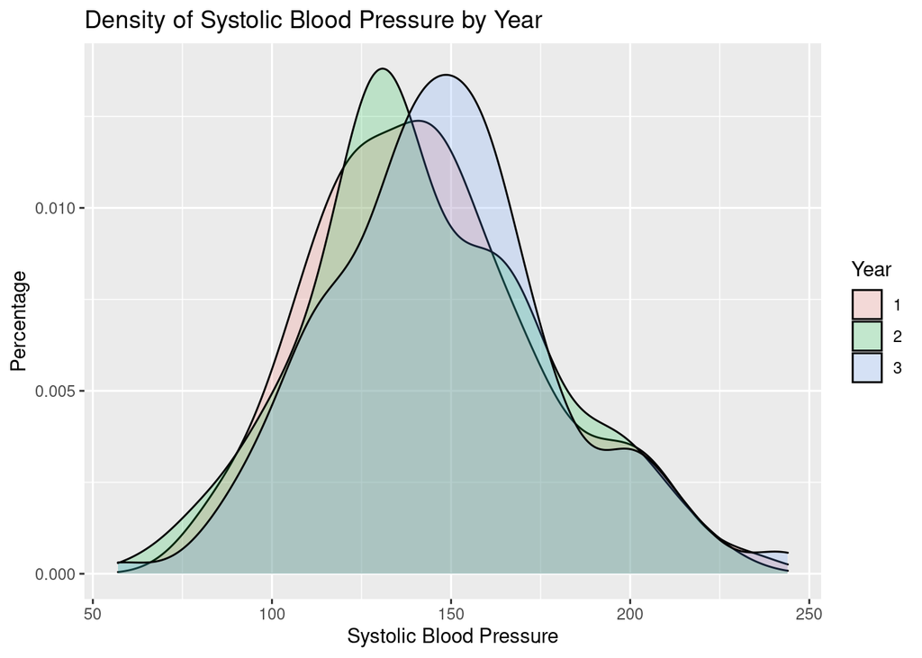

```r
ggplot(df, aes(x = sysbp, fill = as.factor(year)))  + geom_density(alpha = 0.2)+  labs(x = "Systolic Blood Pressure", y = "Percentage", fill = "Year", title = "Density of Systolic Blood Pressure by Year")
```

### diasbp

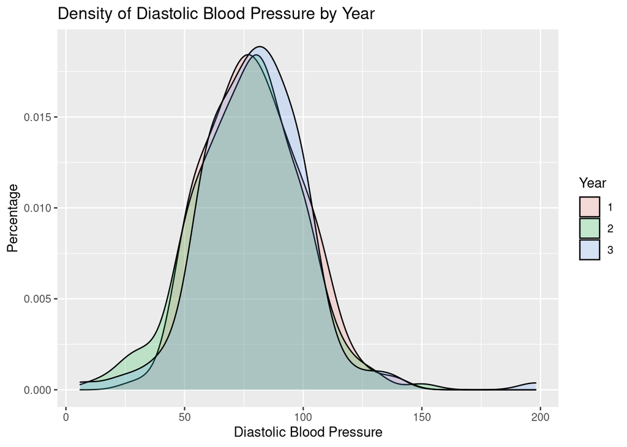

```r
ggplot(df, aes(x = diasbp, fill = as.factor(year)))  + geom_density(alpha = 0.2) +  labs(x = "Diastolic Blood Pressure", y = "Percentage", fill = "Year", title = "Density of Diastolic Blood Pressure by Year")
```

### bmi

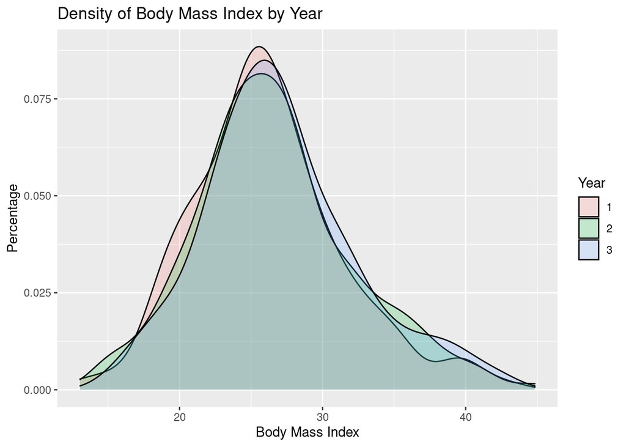

```r
ggplot(df, aes(x = bmi, fill = as.factor(year)))  + geom_density(alpha = 0.2) +  labs(x = "Body Mass Index", y = "Percentage", fill = "Year", title = "Density of Body Mass Index by Year")
```

### cvd

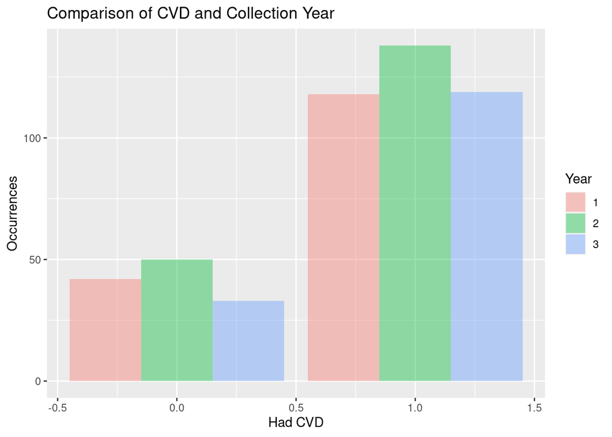

```r
ggplot(df, aes(x = cvd, fill = as.factor(year))) + geom_bar(alpha = 0.4, position="dodge") +  labs(x = "Had CVD", y = "Occurrences", fill = "Year", title = "Comparison of CVD and Collection Year")
```

### afb

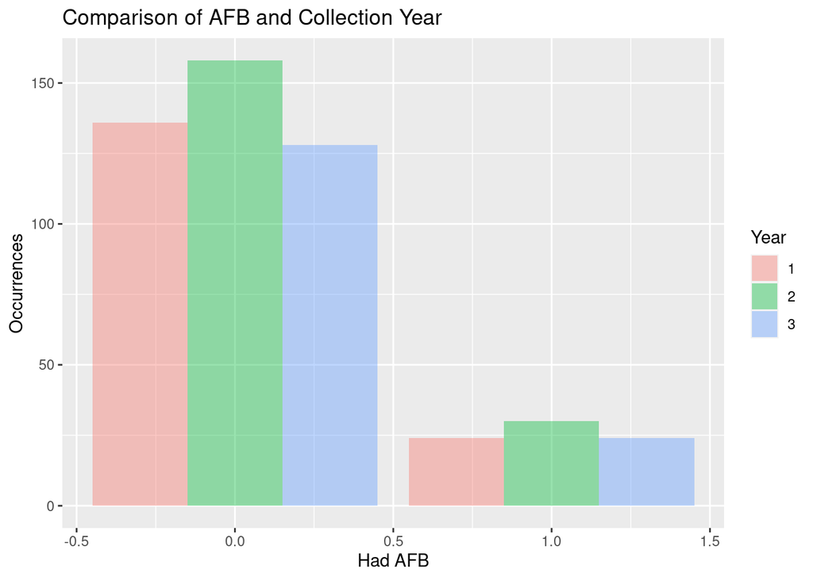

```r
ggplot(df, aes(x = afb, fill = as.factor(year))) + geom_bar(alpha = 0.4, position="dodge") +  labs(x = "Had AFB", y = "Occurrences", fill = "Year", title = "Comparison of AFB and Collection Year")
```

### sho

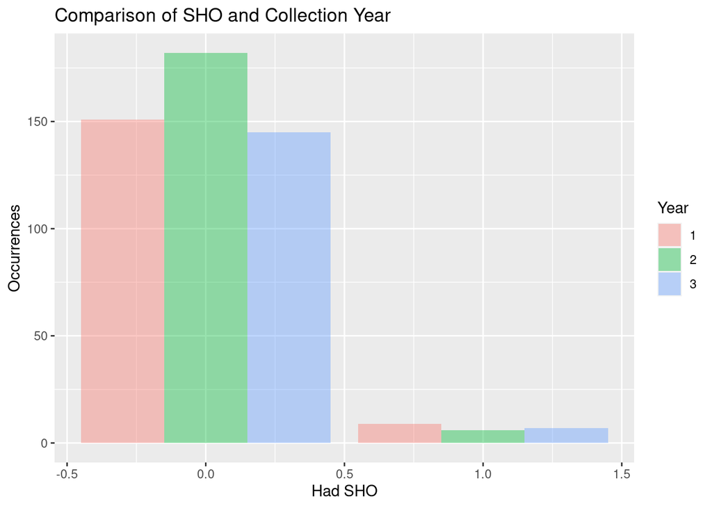

```r
ggplot(df, aes(x = sho, fill = as.factor(year))) + geom_bar(alpha = 0.4, position="dodge") +  labs(x = "Had SHO", y = "Occurrences", fill = "Year", title = "Comparison of SHO and Collection Year")
```

### chf

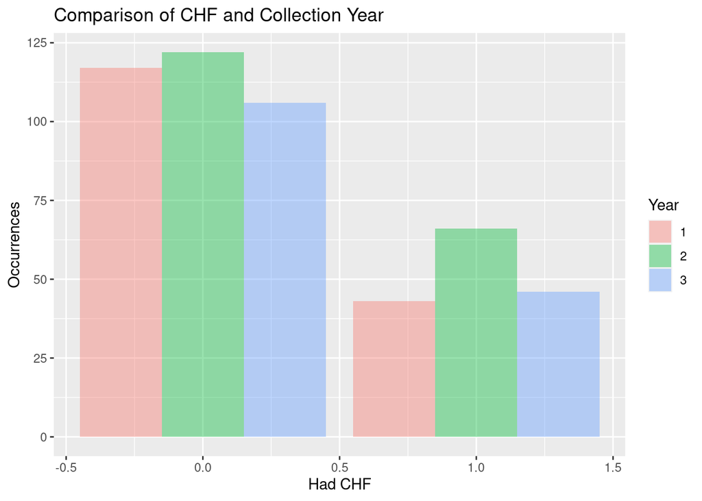

```r
ggplot(df, aes(x = chf, fill = as.factor(year))) + geom_bar(alpha = 0.4, position="dodge") +  labs(x = "Had CHF", y = "Occurrences", fill = "Year", title = "Comparison of CHF and Collection Year")
```

### av3

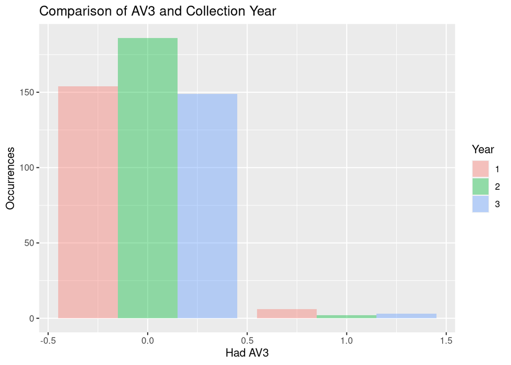

```r
ggplot(df, aes(x = av3, fill = as.factor(year))) + geom_bar(alpha = 0.4, position="dodge") +  labs(x = "Had AV3", y = "Occurrences", fill = "Year", title = "Comparison of AV3 and Collection Year")
```

### miord

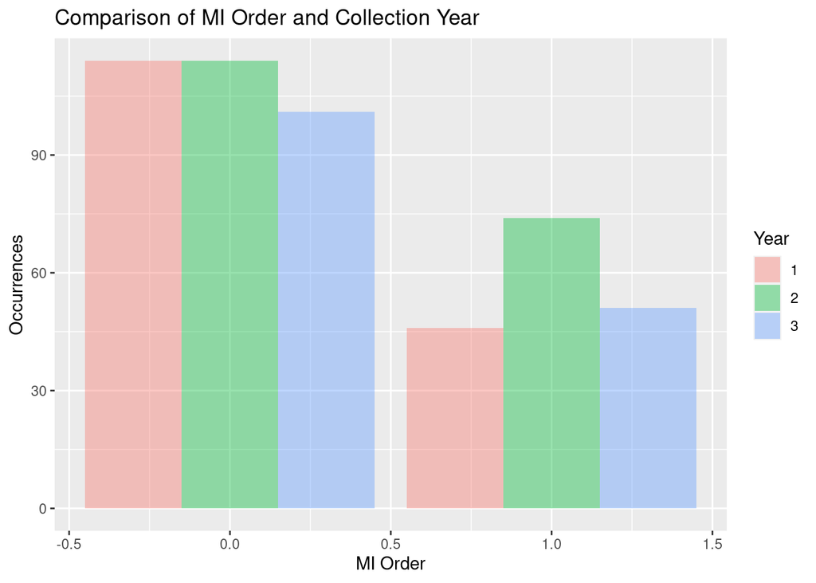

```r
ggplot(df, aes(x = miord, fill = as.factor(year))) + geom_bar(alpha = 0.4, position="dodge") +   labs(x = "MI Order", y = "Occurrences", fill = "Year", title = "Comparison of MI Order and Collection Year")
```

### mitype

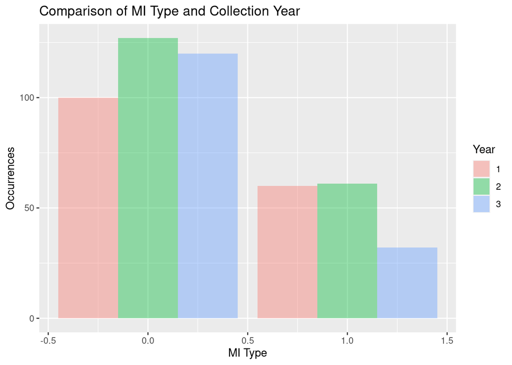

```r
ggplot(df, aes(x = mitype, fill = as.factor(year))) + geom_bar(alpha = 0.4, position="dodge") + labs(x = "MI Type", y = "Occurrences", fill = "Year", title = "Comparison of MI Type and Collection Year")
```

### dstat

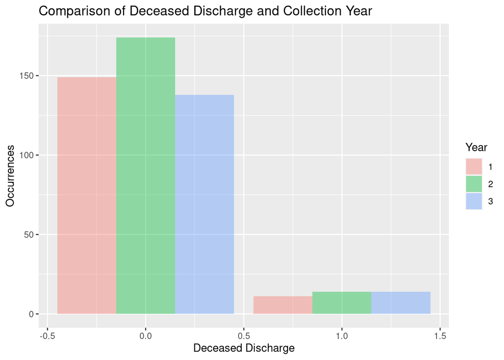

```r
ggplot(df, aes(x = dstat, fill = as.factor(year))) + geom_bar(alpha = 0.4, position="dodge") +  labs(x = "Deceased Discharge", y = "Occurrences", fill = "Year", title = "Comparison of Deceased Discharge and Collection Year")
```

# Reviewing difference in Life and Death

### age

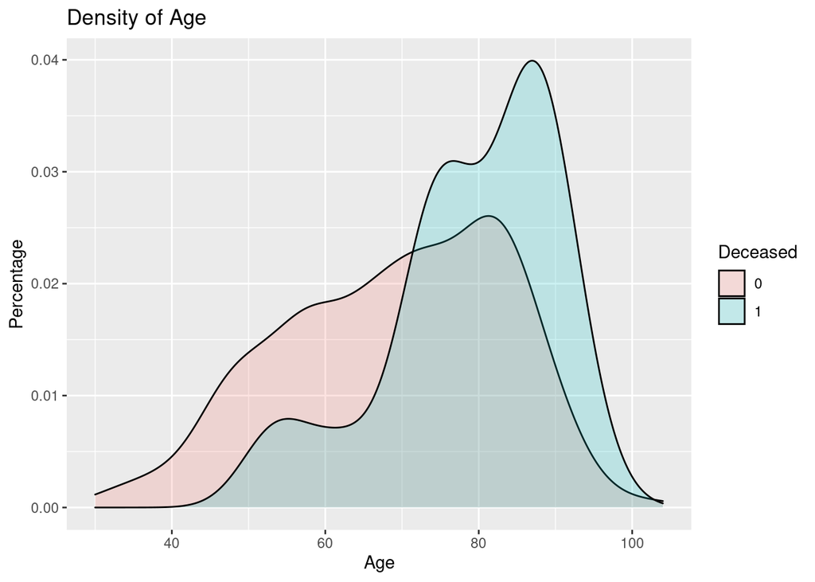

```r
ggplot(df, aes(x = age, fill = as.factor(dstat)))  + geom_density(alpha = 0.2) +  labs(x = "Age", y = "Percentage", fill = "Deceased", title = "Density of Age")
```

### gender

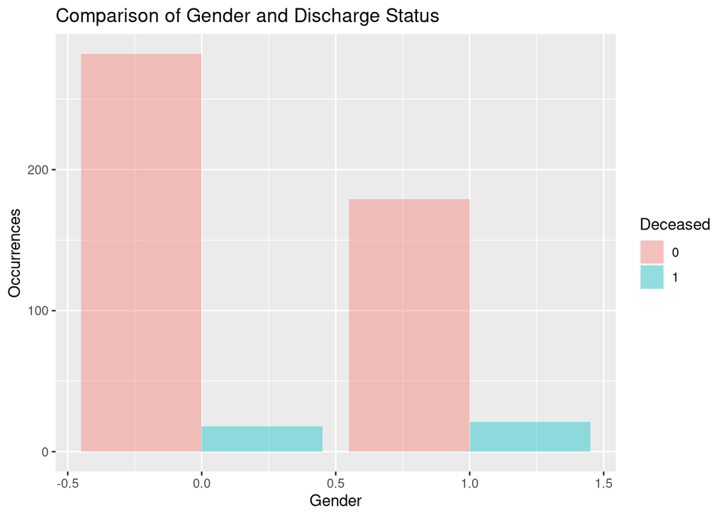

```r
ggplot(df, aes(x = gender, fill = as.factor(dstat))) + geom_bar(alpha = 0.4, position="dodge") +  labs(x = "Gender", y = "Occurrences", fill = "Deceased", title = "Comparison of Gender and Discharge Status")
```

### hr

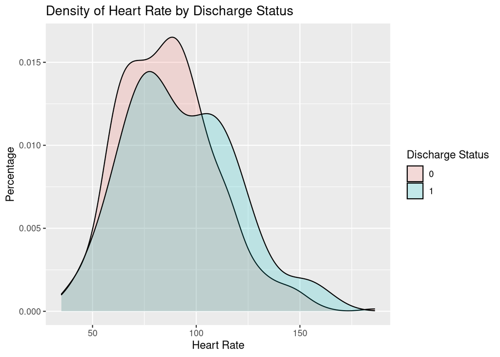

```r
ggplot(df, aes(x = hr, fill = as.factor(dstat)))  + geom_density(alpha = 0.2)  +  labs(x = "Heart Rate", y = "Percentage", fill = "Discharge Status", title = "Density of Heart Rate by Discharge Status")
```

### sysbp

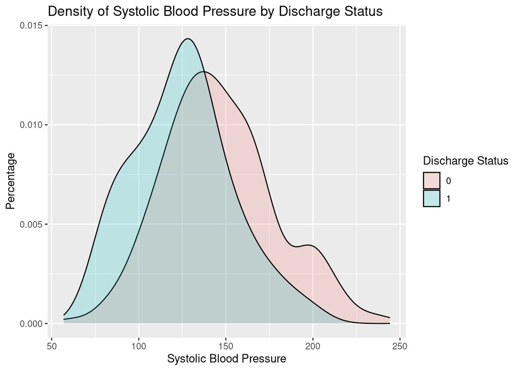

```r
ggplot(df, aes(x = sysbp, fill = as.factor(dstat)))  + geom_density(alpha = 0.2)  +  labs(x = "Systolic Blood Pressure", y = "Percentage", fill = "Discharge Status", title = "Density of Systolic Blood Pressure by Discharge Status")
```

### diasbp

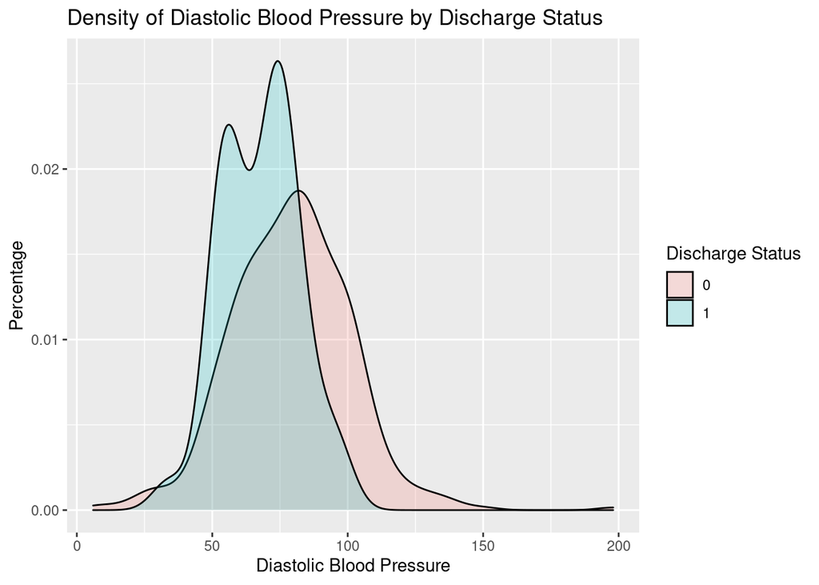

```r
ggplot(df, aes(x = diasbp, fill = as.factor(dstat)))  + geom_density(alpha = 0.2)  +  labs(x = "Diastolic Blood Pressure", y = "Percentage", fill = "Discharge Status", title = "Density of Diastolic Blood Pressure by Discharge Status")
```

### bmi

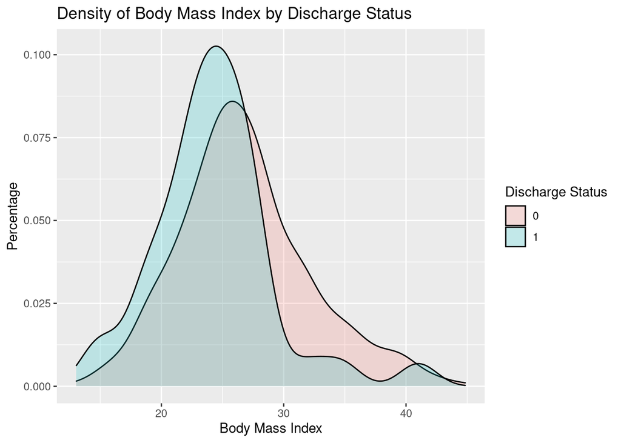

```r
ggplot(df, aes(x = bmi, fill = as.factor(dstat)))  + geom_density(alpha = 0.2) +  labs(x = "Body Mass Index", y = "Percentage", fill = "Discharge Status", title = "Density of Body Mass Index by Discharge Status")
```

### cvd

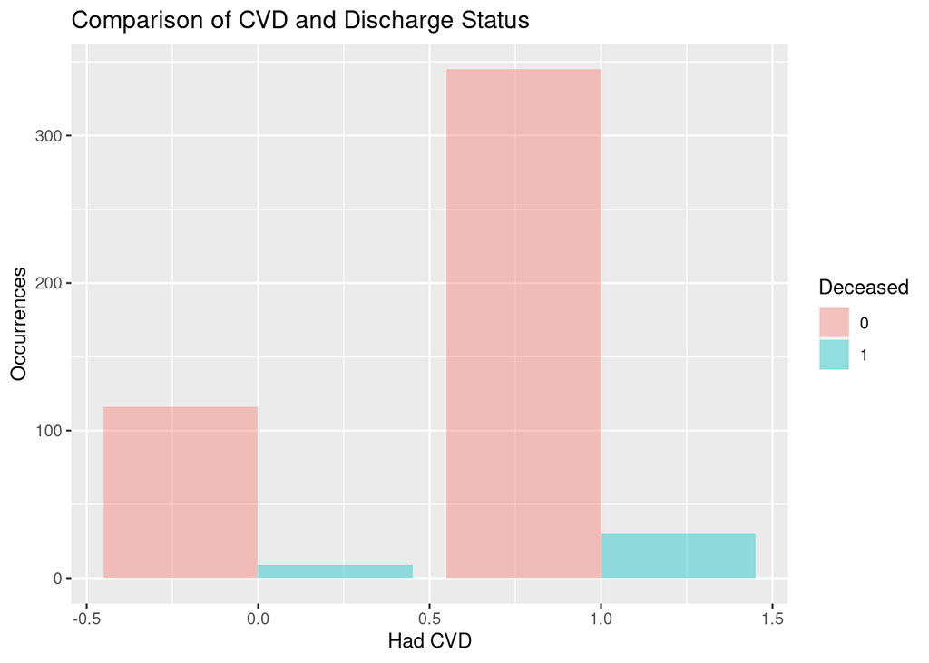

```r
ggplot(df, aes(x = cvd, fill = as.factor(dstat))) + geom_bar(alpha = 0.4, position="dodge") +  labs(x = "Had CVD", y = "Occurrences", fill = "Deceased", title = "Comparison of CVD and Discharge Status")
```

### afb

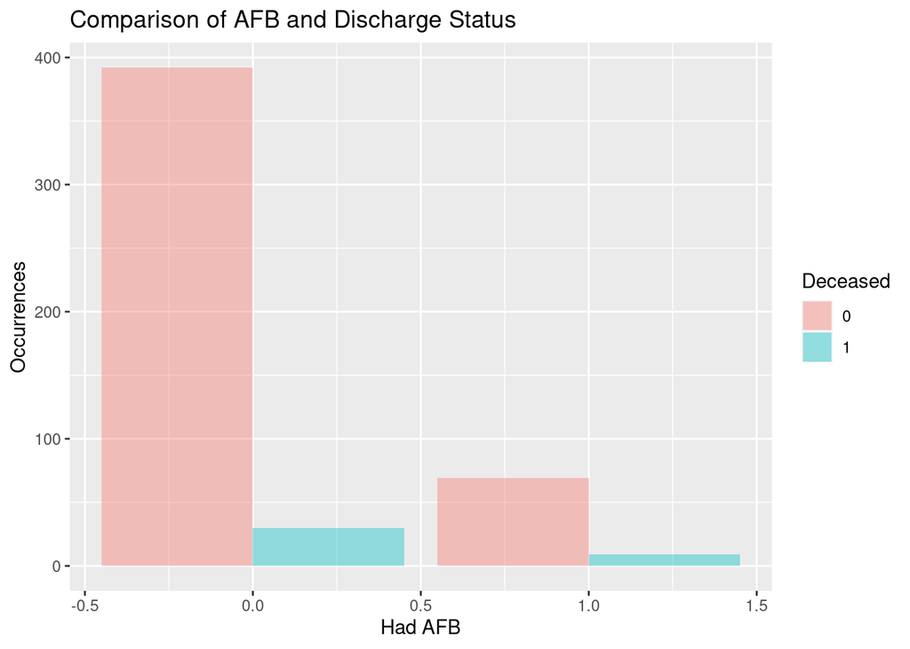

```r
ggplot(df, aes(x = afb, fill = as.factor(dstat))) + geom_bar(alpha = 0.4, position="dodge") +  labs(x = "Had AFB", y = "Occurrences", fill = "Deceased", title = "Comparison of AFB and Discharge Status")
```

### sho

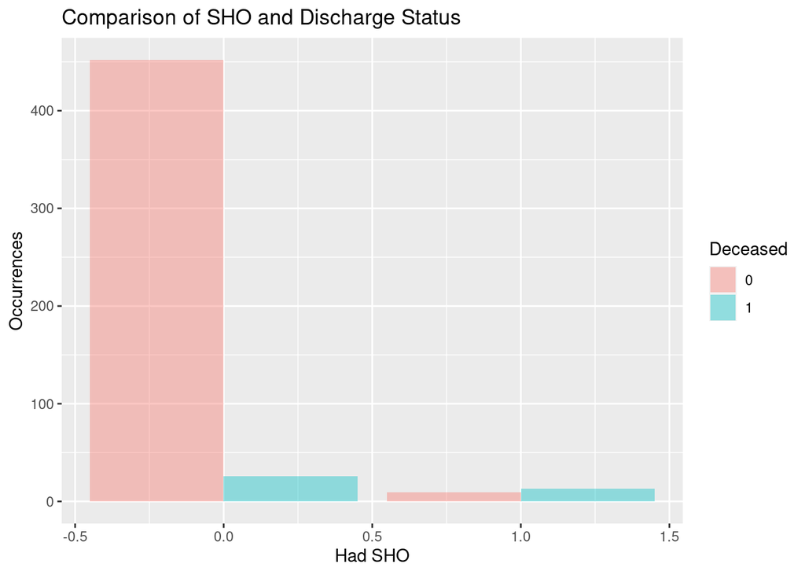

```r
ggplot(df, aes(x = sho, fill = as.factor(dstat))) + geom_bar(alpha = 0.4, position="dodge") +  labs(x = "Had SHO", y = "Occurrences", fill = "Deceased", title = "Comparison of SHO and Discharge Status")
```

### chf

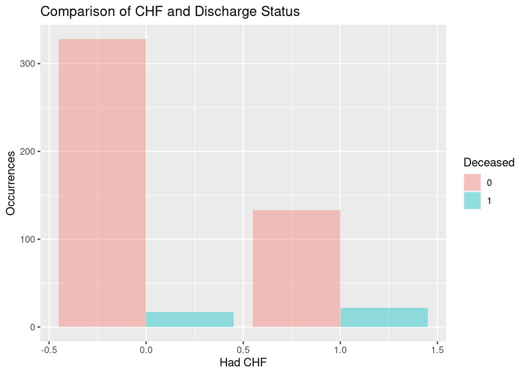

```r
ggplot(df, aes(x = chf, fill = as.factor(dstat))) + geom_bar(alpha = 0.4, position="dodge") +  labs(x = "Had CHF", y = "Occurrences", fill = "Deceased", title = "Comparison of CHF and Discharge Status")
```

### av3

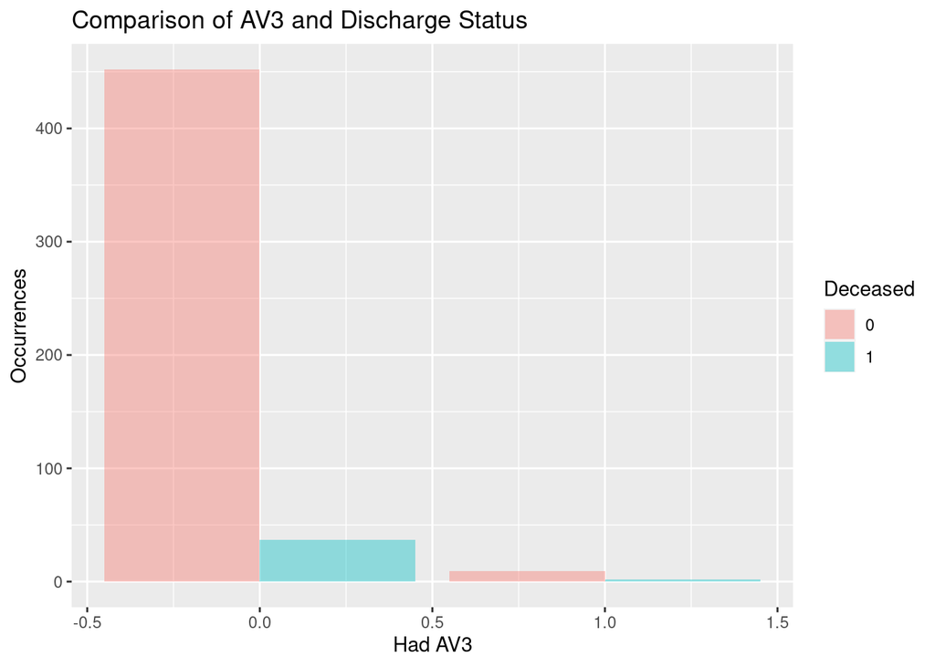

```r
ggplot(df, aes(x = av3, fill = as.factor(dstat))) + geom_bar(alpha = 0.4, position="dodge") +  labs(x = "Had AV3", y = "Occurrences", fill = "Deceased", title = "Comparison of AV3 and Discharge Status")
```

### miord

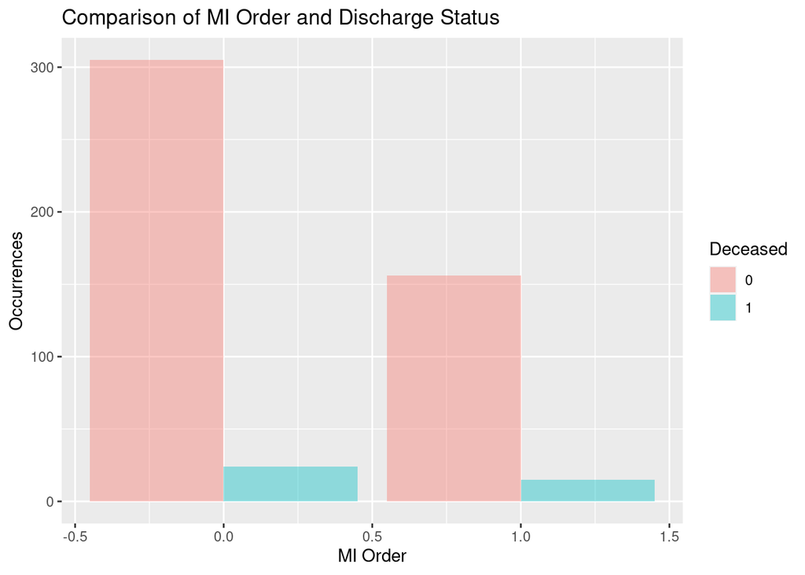

```r
ggplot(df, aes(x = miord, fill = as.factor(dstat))) + geom_bar(alpha = 0.4, position="dodge") +  labs(x = "MI Order", y = "Occurrences", fill = "Deceased", title = "Comparison of MI Order and Discharge Status")
```

### mitype

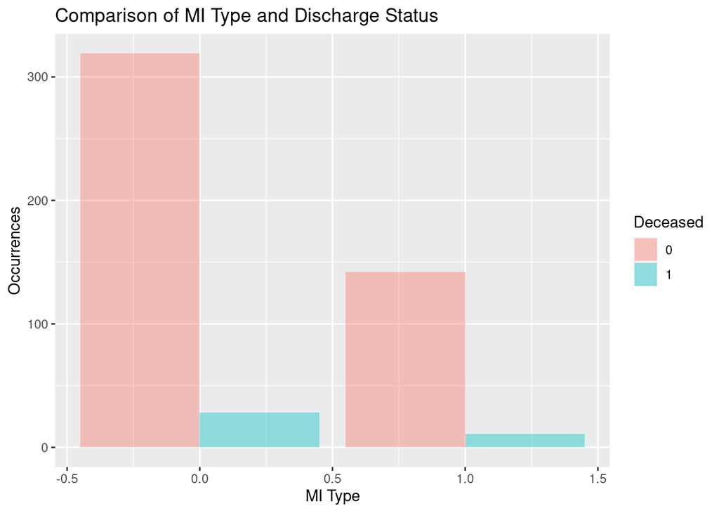

```r
ggplot(df, aes(x = mitype, fill = as.factor(dstat))) + geom_bar(alpha = 0.4, position="dodge") +  labs(x = "MI Type", y = "Occurrences", fill = "Deceased", title = "Comparison of MI Type and Discharge Status")
```

## Bi-Variate Analysis

### Pearson test for Linearity

```r
# drop non numeric rows here
sub <- cor(df[, c("age", 'bmi','sysbp','diasbp', 'hr')])
round(sub, 2)
```

```
##          age   bmi sysbp diasbp    hr
## age     1.00 -0.40 -0.02  -0.21  0.15
## bmi    -0.40  1.00  0.12   0.18 -0.06
## sysbp  -0.02  0.12  1.00   0.61 -0.01
## diasbp -0.21  0.18  0.61   1.00  0.09
## hr      0.15 -0.06 -0.01   0.09  1.00
```

# Train Validate Test Split

```r
set.seed(101011)
ind <- sample(3, nrow(df), replace = TRUE, prob = c(0.6, 0.25, 0.15))
train <- df[ind == 1, ]
train.label <- train[, ncol(train)]

validate <- df[ind == 2, ]
validate.label <- validate[, ncol(validate)]

test <- df[ind == 3, ]
test.label <- test[, ncol(test)]
print(table(ind))
```

```
## ind
##   1   2   3
## 313 112  75
```